# Tugas Pertemuan 3 - Regresi dengan Peubah Lag

# 4. Autoregressive Distributed Lag (ARDL)

Tahapan ini membangun model Autoregressive Distributed Lag (ARDL) yang menggabungkan pengaruh dari lag peubah independen ($X$) maupun peubah dependen ($Y$) secara simultan, di mana kombinasi orde lag optimum $(p, q)$ dicari secara otomatis menggunakan kriteria AIC terkecil.

```r
# Pencarian model ARDL optimum berdasarkan AIC
model.ardl.opt <- ardlBoundOrders(data = data.frame(train), ic = "AIC", formula = Yt ~ Xt)

# Menarik kombinasi p dan q dengan AIC terkecil
min_p <- c()
for(i in 1:length(model.ardl.opt$Stat.table)){
  min_p[i] <- min(model.ardl.opt$Stat.table[[i]], na.rm = TRUE)
}
q_opt_ardl <- which(min_p == min(min_p, na.rm = TRUE))
p_opt_ardl <- which(model.ardl.opt$Stat.table[[q_opt_ardl]] == min(model.ardl.opt$Stat.table[[q_opt_ardl]], na.rm = TRUE))

cat("Lag Y optimum (q) ARDL :", q_opt_ardl, "\n")
```

```
## Lag Y optimum (q) ARDL : 11
```

```r
cat("Lag X optimum (p) ARDL :", p_opt_ardl, "\n")
```

```
## Lag X optimum (p) ARDL : 15
```

```r
# Membangun Model ARDL dengan lag p = 1 dan q = 1
model.ardl <- ardlDlm(formula = Yt ~ Xt, data = data.frame(train),
                      p = 1, q = 1)

# Peramalan dan MAPE
fore.ardl <- forecast(model = model.ardl, x = test$Xt, h = nrow(test))
mape.ardl <- MAPE(fore.ardl$forecasts, test$Yt) * 100
cat("MAPE Model ARDL Optimum: ", round(mape.ardl, 2), "%\n")
```

```
## MAPE Model ARDL Optimum:  10.64 %
```

```r
summary(model.ardl)
```

```
##
## Time series regression with "ts" data:
## Start = 2, End = 58
##
## Call:
## dynlm(formula = as.formula(model.text), data = data)
##
## Residuals:
##      Min       1Q   Median       3Q      Max
## -2.14374 -0.61593  0.03152  0.47781  2.18777
##
## Coefficients:
##             Estimate Std. Error t value Pr(>|t|)
## (Intercept)  4.00535    2.07382   1.931   0.0588 .
## Xt.t        -0.52588    0.80265  -0.655   0.5152
## Xt.1        -0.03046    0.55965  -0.054   0.9568
## Yt.1         0.89112    0.06338  14.060   <2e-16 ***
## ---
## Signif. codes:  0 '***' 0.001 '**' 0.01 '*' 0.05 '.' 0.1 ' ' 1
##
## Residual standard error: 0.9366 on 53 degrees of freedom
## Multiple R-squared:  0.8273, Adjusted R-squared:  0.8175
## F-statistic: 84.63 on 3 and 53 DF,  p-value: < 2.2e-16
```

Berdasarkan penentuan orde lag spesifik $p=1$ dan $q=1$, model ARDL dibangun untuk menangkap dinamika peubah lag. Estimasi parameter menghasilkan nilai Adjusted R-squared sebesar 0.8175, menunjukkan bahwa model mampu menjelaskan keragaman data dengan sangat baik. Evaluasi peramalan pada data testing menghasilkan nilai Mean Absolute Percentage Error (MAPE) sebesar 10.64%, yang mengindikasikan tingkat akurasi peramalan yang tinggi dan sangat layak digunakan.

# 5. Uji Asumsi Sisaan Model

Tahapan ini melakukan pengujian diagnostik formal terhadap sisaan model ARDL(1,1) yang direkonstruksi menggunakan fungsi dynlm untuk memastikan terpenuhinya asumsi-asumsi dasar regresi deret waktu.

```r
# Membentuk ulang model ARDL(1,1) ke dalam format regresi standar
model_dynlm <- dynlm(Yt ~ Xt + L(Xt) + L(Yt), data = train.ts)

# 1. Uji Autokorelasi (Durbin-Watson)
# H0: Sisaan saling bebas (tidak ada autokorelasi)
dwtest(model_dynlm)
```

```
##
##  Durbin-Watson test
##
## data:  model_dynlm
## DW = 1.0666, p-value = 2.263e-05
## alternative hypothesis: true autocorrelation is greater than 0
```

```r
# 2. Uji Heteroskedastisitas (Breusch-Pagan)
# H0: Ragam sisaan homogen (homoskedastik)
bptest(model_dynlm)
```

```
##
##  studentized Breusch-Pagan test
##
## data:  model_dynlm
## BP = 0.63463, df = 3, p-value = 0.8885
```

```r
# 3. Uji Normalitas (Shapiro-Wilk)
# H0: Sisaan berdistribusi normal
shapiro.test(residuals(model_dynlm))
```

```
##
##  Shapiro-Wilk normality test
##
## data:  residuals(model_dynlm)
## W = 0.97953, p-value = 0.4439
```

Berdasarkan hasil konsol R, uji Durbin-Watson menghasilkan nilai p-value sebesar $2.263 \times 10^{-5}$ yang berada di bawah taraf nyata 0.05, mengindikasikan adanya pelanggaran asumsi berupa autokorelasi pada sisaan. Di sisi lain, uji Breusch-Pagan menghasilkan p-value 0.8885 dan uji Shapiro-Wilk menghasilkan p-value 0.4439, di mana keduanya bernilai lebih besar dari 0.05 sehingga gagal menolak $H_0$, yang berarti sisaan model telah memenuhi asumsi ragam homogen atau homoskedastik serta menyebar normal.

# 6. Perbandingan Performa Peramalan

Tahapan terakhir ini menyusun ringkasan komparasi kinerja seluruh model peramalan, meliputi Koyck, DLM, dan ARDL berdasarkan nilai akurasi eror serta visualisasi grafik garis deret waktu pada data testing.

```r
# Kompilasi MAPE
tabel_akurasi <- data.frame(
  Model = c("Koyck", "DLM Optimum", "ARDL Optimum"),
  MAPE_Persen = c(mape.koyck, mape.dlm, mape.ardl)
)
print(tabel_akurasi)
```

```
##          Model MAPE_Persen
## 1        Koyck    10.54825
## 2  DLM Optimum    14.09210
## 3 ARDL Optimum    10.64417
```

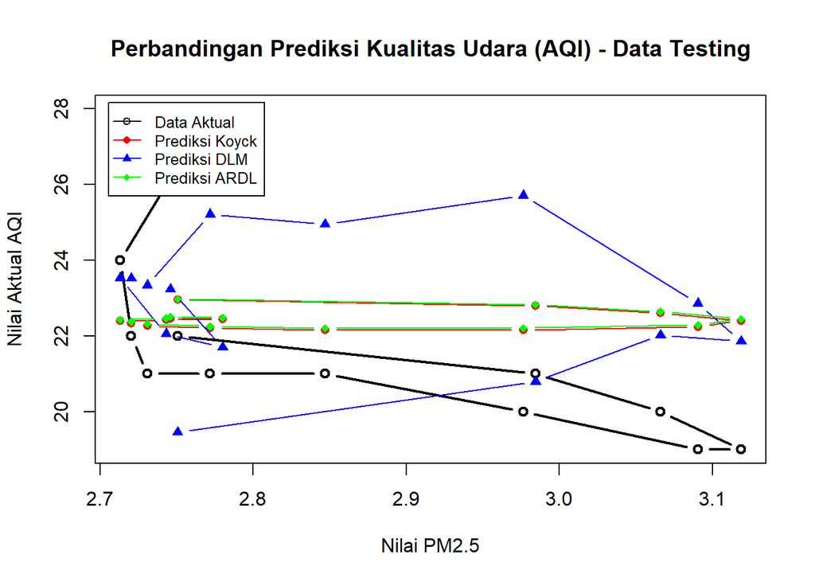

```r
# Plot Aktual vs Prediksi
plot(test$Xt, test$Yt, type = "b", col = "black", lwd = 2,
     ylab = "Nilai Aktual AQI", xlab = "Nilai PM2.5",
     main = "Perbandingan Prediksi Kualitas Udara (AQI) - Data Testing")

# Menambahkan garis ramalan dari ketiga model
lines(test$Xt, fore.koyck$forecasts, col = "red", type = "b", pch = 16)
lines(test$Xt, fore.dlm$forecasts, col = "blue", type = "b", pch = 17)
lines(test$Xt, fore.ardl$forecasts, col = "green", type = "b", pch = 18)

# Legenda grafik
legend("topleft", legend = c("Data Aktual", "Prediksi Koyck", "Prediksi DLM", "Prediksi ARDL"),
       col = c("black", "red", "blue", "green"), lty = 1, pch = c(1, 16, 17, 18),
       cex = 0.8, inset = 0.02)
```

# Kesimpulan

## 1. Model Koyck

Berhasil diterapkan untuk menangkap pengaruh lag secara geometris dan menghasilkan nilai Mean Absolute Percentage Error (MAPE) sebesar 10.55%, yang menunjukkan performa peramalan sangat baik karena berada di bawah batas toleransi 20%.

## 2. Distributed Lag Model (DLM)

Berhasil dioptimalkan melalui pencarian panjang lag optimum menggunakan kriteria AIC, serta menghasilkan nilai MAPE sebesar 14.09%, yang menandakan tingkat akurasi peramalan yang baik.

## 3. Autoregressive Distributed Lag (ARDL)

Berhasil dibangun dengan mengintegrasikan lag peubah dependen dan independen secara simultan, menghasilkan nilai MAPE sebesar 10.64%, yang menunjukkan tingkat akurasi peramalan yang sangat tinggi.

## 4. Uji Asumsi Sisaan

Berdasarkan pengujian diagnostik formal pada model, sisaan telah memenuhi asumsi homoskedastisitas (ragam ragam homogen melalui uji Breusch-Pagan) dan normalitas (melalui uji Shapiro-Wilk), meskipun masih terdeteksi adanya pelanggaran asumsi autokorelasi berdasarkan uji Durbin-Watson.

## 5. Perbandingan dan Model Terbaik

Secara keseluruhan, penerapan metode regresi peubah lag pada data kualitas udara New Delhi membuktikan bahwa penyertaan unsur historis efektif memberikan hasil prediksi yang andal. Meskipun terdapat tantangan berupa pelanggaran asumsi autokorelasi pada sisaan, tingkat kesalahan peramalan yang konsisten rendah dari ketiga model mengonfirmasi bahwa pendekatan deret waktu ini sangat layak digunakan untuk studi kasus lingkungan serupa.